# Homework #6

Blake Inderski

4/16/2019

```r
library("dplyr")
library("tidyr")
library("tidyverse")
```

```r
library("ggplot2")
library("readxl")
library("ggrepel")
library("RColorBrewer")
```

## Top dogs

In this homework, you will try to reproduce the fantastic infographic for [top dogs](https://informationisbeautiful.net/visualizations/best-in-show-whats-the-top-data-dog/), originally produced by David McCandless. The raw data can be found [here](https://docs.google.com/spreadsheets/d/1l_HfF5EaN-QgnLc2UYdCc7L2CVrk0p3VdGB1godOyhk/edit#gid=10). You can download this file by File – Download As – Microsoft Excel (.xlsx).

**Submission instructions**: Create a folder named `ds202_hw6`, and name the RMarkDown file including your solutions `hw6.Rmd` under this folder. For the submission, create a GitHub repository named `ds202_hw6` under your GitHub account, and push both `hw6.Rmd` and the knitted `hw6.html` before the deadline. I will assume you use the same GitHub username as for your HW5 submission. The latest version of your homework appearing on GitHub before the deadline is graded. *It is crucial to follow the exact folder structure and file names*, so that your homework can be reproduced and graded by an automated script. This homework is **due on April 25** before class.

1. Import the data and clean appropriately. To read in the data, you can use `readxl::read_xlsx('fileNameHere', sheet='sheetNameHere')`. Required data are in the sheets `Best in show` and `Best in show full sheet`. Take extra care on the column names and the first few rows of the data frame after read in.

```r
#data1 <- readxl::read_xlsx("KIB\ -\ Best\ in\ Show\ (public).xlsx", sheet="Best in show")
data2 <- readxl::read_xlsx("KIB\ -\ Best\ in\ Show\ (public).xlsx", sheet="Best in show full sheet")
```

[output not shown]

```r
data2 <- data2[,colSums(is.na(data2))<nrow(data2)]
data2 <- data2 %>% select(1, 2, 3, 5, 9, 27)
data2 <- data2[-c(1, 2, 3), ]
colnames(data2) <- c("breed", "type", "score", "popularity", "intelligence_raw", "size")
data2$score <- as.numeric(data2$score)
data2$popularity <- as.numeric(data2$popularity)
data2$intelligence_raw <- as.numeric(data2$intelligence_raw)
data2$type <- as.factor(data2$type)
#levels(data2$type) #correct level order
data2$size <- as.factor(data2$size)
#levels(data2$size) #levels need to be reversed
data2$size <- fct_rev(data2$size)

data2 <- data2 %>% mutate(intelligence = ifelse(intelligence_raw >= 0.5, "clever", "dumb"))
data2$intelligence <- as.factor(data2$intelligence)
#levels(data2$intelligence) #levels need to be reversed
data2$intelligence <- fct_rev(data2$intelligence)

data2 <- data2 %>% drop_na()

head(data2)
```

```
## # A tibble: 6 x 7
##   breed         type   score popularity intelligence_raw size  intelligence
##   <chr>         <fct>  <dbl>      <dbl>            <dbl> <fct> <fct>
## 1 Border Collie herdi…  3.64         39            1     medi… clever
## 2 Border Terri… terri…  3.61         61            0.701 small clever
## 3 Brittany      sport…  3.54         30            0.805 medi… clever
## 4 Cairn Terrier terri…  3.53         48            0.609 small clever
## 5 Welsh Spring… sport…  3.34         81            0.690 medi… clever
## 6 English Cock… sport…  3.33         51            0.816 medi… clever
```

2. Create a graphics similar to the [top dogs](https://informationisbeautiful.net/visualizations/best-in-show-whats-the-top-data-dog/) figure. Your figure need to display the following information with appropriate plotting elements:
- breed of dog
- type of dog (work, toy, etc.)
- size of dog
- data score
- popularity
- intelligence of the dog
- appropriate legends & explanation

Hints and Notes:

- The breed of dog can be displayed without the silhouttes (text only is fine)
- Avoid (too much) overlap!
- Choose a good color scheme.
- Your submission is supposed to be fully reproducible, i.e. the TA and I will ‘knit’ your submission in RStudio.

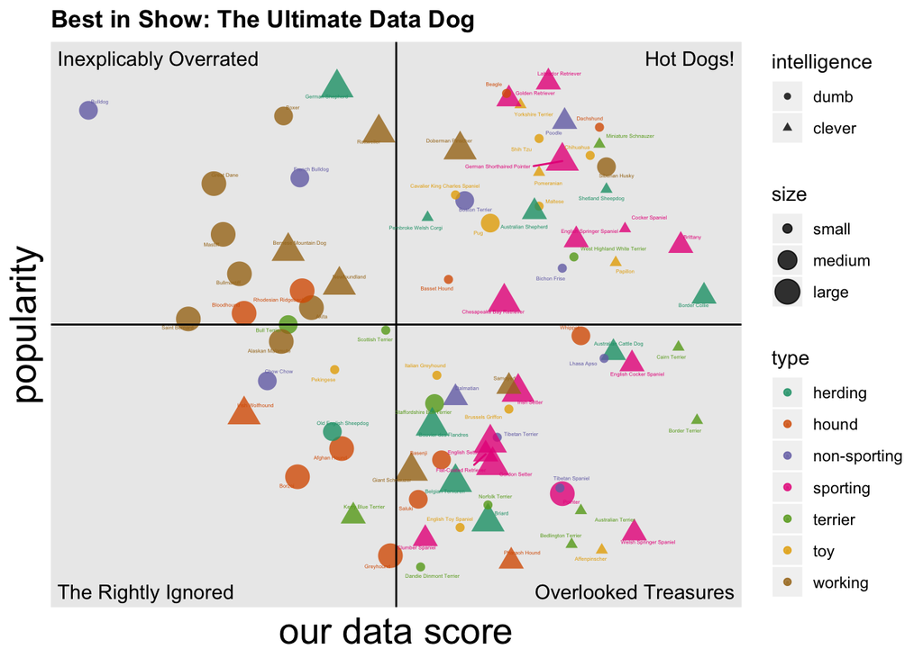

```r
min_score <- min(as.vector(data2$score), na.rm=TRUE)
max_score <- max(as.vector(data2$score), na.rm=TRUE)
score_range <- max_score-min_score
score_middle <- score_range/2 + min_score
min_popularity <- -max(as.vector(data2$popularity), na.rm=TRUE)
max_popularity <- -min(as.vector(data2$popularity), na.rm=TRUE)
popularity_range <- max_popularity-min_popularity
popularity_middle <- popularity_range/2 + min_popularity
#size_convert = c("small" = 1, "medium" = 2, "large" = 3)

plot <- ggplot(data2, aes(x=score, y=-popularity, label=breed)) +
  geom_point(alpha = 0.8, aes(shape=intelligence, color=type, size=size)) +
  #size=size_convert[size])) +
  labs(title = "Best in Show: The Ultimate Data Dog", x = "our data score", y = "popularity") +
  coord_cartesian(xlim=c(min_score-score_range*0.01, max_score+score_range*0.01),
                  ylim=c(min_popularity-popularity_range*0.03, max_popularity+popularity_range*0.03)) +
  geom_vline(xintercept = score_middle, size=0.5) +
  geom_hline(yintercept = popularity_middle, size=0.5) +
  theme(axis.ticks.x=element_blank(),
        axis.ticks.y=element_blank(),
        axis.text.x=element_blank(),
        axis.text.y=element_blank(),
        panel.grid.minor = element_blank(),
        panel.grid.major = element_blank(),
        axis.title.x = element_text(size = 20),
        axis.title.y = element_text(size = 20),
        plot.title = element_text(lineheight=.8, face="bold")) +
  #https://cran.r-project.org/web/packages/ggrepel/vignettes/ggrepel.html
  geom_text_repel(aes(color=type), size = 1) +
  #scale_size_continuous(range = c(1, 3))
  scale_size_discrete(breaks=levels(data2$size)) +
  annotate("text", x=min_score-score_range*0.05,
           y=min_popularity-popularity_range*0.05, label="The Rightly Ignored", hjust=0) +
  annotate("text", x=max_score+score_range*0.05,
           y=max_popularity+popularity_range*0.05, label="Hot Dogs!", hjust=1) +
  annotate("text", x=min_score-score_range*0.05,
           y=max_popularity+popularity_range*0.05, label="Inexplicably Overrated", hjust=0) +
  annotate("text", x=max_score+score_range*0.05,
           y=min_popularity-popularity_range*0.05, label="Overlooked Treasures", hjust=1) +
  guides(shape = guide_legend(order = 1),
         size = guide_legend(order = 2),
         color = guide_legend(order = 3)) +
  scale_color_brewer(palette="Dark2")
plot
```